# 2b

Yiqiao Yin

1/14/2021

# Homework: 2b

This homework let us continue with some interesting simulations.

## Write a program

Let me pursue this with regular *R* first.

```r
# Define program
genY = function(alpha, beta, n, x, sigma) {
  error = rnorm(n, 0, sigma)
  return(y = alpha + beta*x + error)
}
```

Next, let me code this in *Stan*.

```r
library(cmdstanr)
cmdstan_path()
```

```
## [1] "C:/Users/eagle/Documents/.cmdstanr/cmdstan-2.25.0"
```

```r
file <- file.path(cmdstan_path(), "examples", "model", "linearModel.stan")
mod <- cmdstan_model(file)
```

```
## Model executable is up to date!
```

```r
mod$print()
```

```
## data {
##   int<lower=0> N;
##   vector[N] x;
##   vector[N] y;
## }
## parameters {
##   real alpha;
##   real beta;
##   real<lower=0> sigma;
## }
## model {
##   y ~ normal(alpha + beta * x, sigma);
## }
```

## In R, simulate fake data

In R, simulate fake data for this model with N=100, x uniformly distributed between 0 and 10, and a, b, sigma taking on the values 2, 3, 0.2.

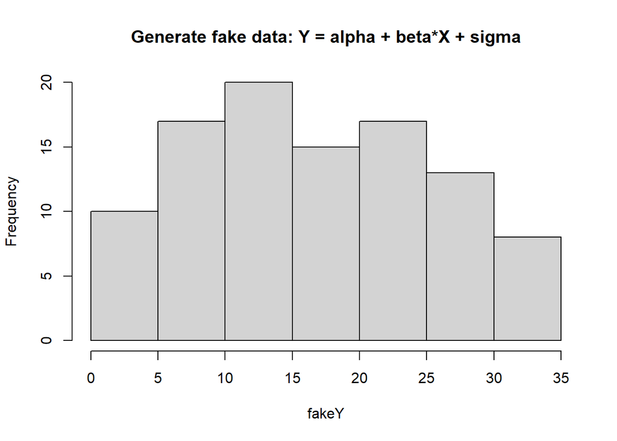

```r
x = runif(100,0,10)
fakeY = genY(alpha = 2, beta = 3, n = 100, x = x, sigma = 0.2)
hist(fakeY, main = "Generate fake data: Y = alpha + beta*X + sigma")
```

## Fit the model

Fit the *Stan* model using your simulated data and check that the true parameter values are approximately recovered. Check also that you get approximately the same answer as from fitting a classical linear regression.

```r
# we can check with linear model
summary(lm(fakeY~x))
```

```
##
## Call:
## lm(formula = fakeY ~ x)
##
## Residuals:
##      Min       1Q   Median       3Q      Max
## -0.37116 -0.08859  0.00970  0.10500  0.42761
##
## Coefficients:
##             Estimate Std. Error t value Pr(>|t|)
## (Intercept) 1.984548   0.033744   58.81   <2e-16 ***
## x           3.004154   0.005904  508.83   <2e-16 ***
## ---
## Signif. codes:  0 '***' 0.001 '**' 0.01 '*' 0.05 '.' 0.1 ' ' 1
##
## Residual standard error: 0.1706 on 98 degrees of freedom
## Multiple R-squared:  0.9996, Adjusted R-squared:  0.9996
## F-statistic: 2.589e+05 on 1 and 98 DF,  p-value: < 2.2e-16
```

We can read off the estimated parameters that $a \approx 2$ and $b \approx 3$.

In *Stan*, we do the following

Next, let us write in *Stan*. Using *mod$sample()* function, we are able to generate MCMC simulation.

```r
# names correspond to the data block in the Stan program
data_list <- list(N = 1e2, x = x, y = fakeY)

fit <- mod$sample(
  data = data_list,
  seed = 123,
  chains = 2,
  parallel_chains = 2,
  refresh = 500
)
```

```
## Running MCMC with 2 parallel chains...
##
## Chain 1 Iteration:    1 / 2000 [  0%]  (Warmup)
## Chain 1 Iteration:  500 / 2000 [ 25%]  (Warmup)
## Chain 1 Iteration: 1000 / 2000 [ 50%]  (Warmup)
## Chain 1 Iteration: 1001 / 2000 [ 50%]  (Sampling)
## Chain 1 Iteration: 1500 / 2000 [ 75%]  (Sampling)
## Chain 1 Iteration: 2000 / 2000 [100%]  (Sampling)
## Chain 2 Iteration:    1 / 2000 [  0%]  (Warmup)
## Chain 2 Iteration:  500 / 2000 [ 25%]  (Warmup)
## Chain 2 Iteration: 1000 / 2000 [ 50%]  (Warmup)
## Chain 2 Iteration: 1001 / 2000 [ 50%]  (Sampling)
## Chain 2 Iteration: 1500 / 2000 [ 75%]  (Sampling)
## Chain 2 Iteration: 2000 / 2000 [100%]  (Sampling)
## Chain 1 finished in 0.1 seconds.
## Chain 2 finished in 0.1 seconds.
##
## Both chains finished successfully.
## Mean chain execution time: 0.1 seconds.
## Total execution time: 0.3 seconds.
```

```r
# check out the summary of the fit
fit$summary()
```

| variable | mean | median | sd | mad | q5 | q95 | rhat | ess_bulk | ess_tail |
| --- | --- | --- | --- | --- | --- | --- | --- | --- | --- |
| lp__ | 124.5365365 | 124.819000 | 1.215448102 | 1.031889600 | 122.2468000 | 125.8830000 | 1.0006655 | 695.3599 | 822.7898 |
| alpha | 1.9826356 | 1.982655 | 0.034839924 | 0.034388907 | 1.9261380 | 2.0401920 | 1.0061415 | 720.9210 | 900.9646 |
| beta | 3.0044742 | 3.004430 | 0.006024664 | 0.005915574 | 2.9946395 | 3.0144920 | 1.0066718 | 752.9170 | 954.0896 |
| sigma | 0.1727113 | 0.171856 | 0.012324863 | 0.013026124 | 0.1531482 | 0.1942151 | 0.9998317 | 1029.9308 | 929.8672 |

We can observe from the above table in *fit&summary()* we have mean of alpha to be approximately 2, mean of beta to be approximately 3, and mean of sigma to be approximately 0.2. This corresponds to the results coming from classical linear regression in *R*.

## Make a single graph

Make a single graph showing a scatterplot of the simulated data and the fitted model.

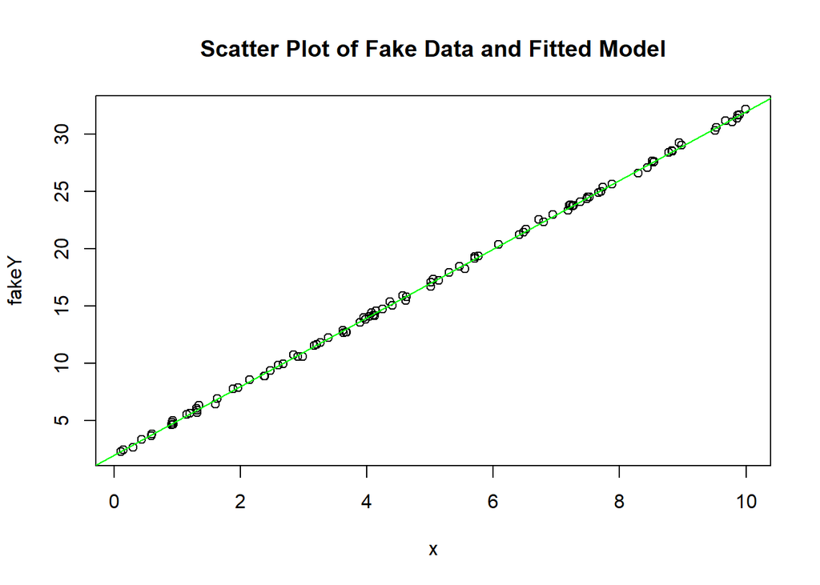

```r
plot(x, fakeY, main = "Scatter Plot of Fake Data and Fitted Model")
abline(a = 2, b = 3, col = "green")
```

## Report

Report on any difficulties you had at any of the above steps.

It took a while to read through the documentation of *Stan*, but after some discussion with classmates it is quite clear. However, I have the following thoughts:

I am not sure what the motivation of using *Stan* is. After carrying out such approach using *Stan*, I understand that the philosophy is to develop a pipeline with ingredients and recipes being user friendly and then the kitchen automatically cooks amazing meal! (In this analogy, the kitchen is *Stan* and since *Stan* compiles *C++* the selling point is that it’s ``faster’’.)

However, in computer science knowledge, a pipeline is convincing if it has more optimal performance in time / space complexity. For example, engineers present two pipelines: (A) program *A* has time of $O(n)$ and space of $O(n)$, and (B) program *B* has time of $O(n^2)$ and space of $O(\exp(n))$. Then obviously (A) is more optimal. I am unclear *Stan* survives this measurement comparing with *apply()* in *R* (also compiled from *C++*), and *numpy*, *random* or *tensorflow* in *Python*.